# Storm Data Analysis using NOAA provided data(1976-2011)

DainaE

Tuesday, March 17, 2015

# Title:

This research presents a study into the Storm Data which is an official publication of the National Oceanic and Atmospheric Administration (NOAA). There is a study done on occurrence of storms and other significant weather phenomena and their intensity to cause loss of life, injuries, significant property damage, and/or disruption to commerce

# Synopsis:

The research involves study into the Storm Data published by National Oceanic and Atmospheric Administration. The objective of the study is to clasify the data to correspond to key events classification , to identify the events which are major causes of impact on Human and Economic loss. The significance of the study is to identify areas of how to improve the event reporting to gather more accurate data and also to propose areas of focus to the municipal regulatories. Scope of the study is limited to the NOAA Storm Database. The limitations in the current analysis of the events would be : 1. The event mapping is done based on the judgement and ability if the author which can be refined and also corrected in certain cases. 2. The time constraint of one week without domain knowledge in the field of weather events can lead to biased judgement

# Data Processing

Read the Storm Data for analysis Data is read from the CSV file

```r
setwd("C://Personal//Coursera//Assignment//Data Storm")
sd_data <- read.csv("repdata-data-StormData.csv.bz2")
library(dplyr)
sd_tbl <- tbl_df(sd_data)
```

# Cleaning Data

Steps involved to get a clean Data

Based on manual analysis of data we understand the kind of errors in the naming of EVTYPE variables. We will replace them to uniformly be one of the 48 valid event types. There are 48 replacements which will be done to clean up the data. We introduce a new column EventMap. We extract all the rows which should correspond to a given valid EVTYPE and save the value in EventMap The file lookupTable is available in github , which gives the strategy for cleanup and the keys used to segregate teh 447 line items based on relevance into the 48 events.

```r
library(splus2R)

events_tbl <- filter(sd_tbl,FATALITIES >0 | INJURIES >0 | CROPDMG >0 | PROPDMG>0 )
events_tbl$EVTYPE <- lowerCase(events_tbl$EVTYPE)
events_tbl <- select(events_tbl,EVTYPE,BGN_DATE, FATALITIES,INJURIES,PROPDMG,PROPDMGEXP,CROPDMG,CROPDMGEXP) %>% group_by(EVTYPE) %>% summarise_each(funs(sum))
#Event list from code book section 2.1.1 copied to the valid_events file
events_validlist <- read.fwf("valid_events",widths = 24)
events_validlist <- validSlotNames(events_validlist)
events_validlist$V1 <- gsub(c(" "),"",events_validlist$V1)
events_tbl <- mutate(events_tbl,EventMap=NA)

#447*8 matrix
dim(events_tbl)
```

```
## [1] 447   9
```

```r
pick.event <- function(x) {as.character(events_validlist$V1[grepl(x,events_validlist$V1)])}
events_tbl$EventMap<- NA
#Clean up data by associating to the right 48 event types

nrow(events_tbl[is.na(events_tbl$EventMap),])
```

```
## [1] 447
```

```r
#25
events_tbl$EventMap[grepl("low tide",events_tbl$EVTYPE)] <- pick.event("Astronomical*")
events_tbl$EventMap[grepl("avalan",events_tbl$EVTYPE)] <- pick.event("Avalanche*")
events_tbl$EventMap[grepl("blizzard",events_tbl$EVTYPE)] <- pick.event("Blizzard*")
events_tbl$EventMap[grepl("dense fog",events_tbl$EVTYPE)] <- pick.event("DenseFog*")
events_tbl$EventMap[grepl("dense smoke",events_tbl$EVTYPE)] <- pick.event("Smoke*")
events_tbl$EventMap[grepl("dust devil",events_tbl$EVTYPE)] <- pick.event("DustDevil*")
events_tbl$EventMap[grepl("dust storm",events_tbl$EVTYPE)] <- pick.event("DustStorm*")
events_tbl$EventMap[grepl("hail",events_tbl$EVTYPE)] <- pick.event("Hail*")
events_tbl$EventMap[grepl("hurricane",events_tbl$EVTYPE)] <- pick.event("Hurricane*")
events_tbl$EventMap[grepl("tropical depression",events_tbl$EVTYPE)] <- pick.event("TropicalDep*")
events_tbl$EventMap[grepl("tropical storm",events_tbl$EVTYPE)] <- pick.event("TropicalStorm*")
events_tbl$EventMap[grepl("tsunami",events_tbl$EVTYPE)] <- pick.event("Tsunami*")
events_tbl$EventMap[grepl("volcanic",events_tbl$EVTYPE)] <- pick.event("Volcanic*")
events_tbl$EventMap[grepl("lakeshore",events_tbl$EVTYPE)] <- pick.event("Lakeshore*")
events_tbl$EventMap[grepl("marine hail",events_tbl$EVTYPE)] <- pick.event("MarineHail*")
events_tbl$EventMap[grepl("marine high wind",events_tbl$EVTYPE)] <- pick.event("MarineHigh*")
events_tbl$EventMap[grepl("marine strong wind",events_tbl$EVTYPE) | grepl("marine mishap",events_tbl$EVTYPE) ] <- pick.event("MarineStrong*")
events_tbl$EventMap[grepl("funnel",events_tbl$EVTYPE)] <- pick.event("FunnelCloud*")
events_tbl$EventMap[grepl("drought",events_tbl$EVTYPE)] <- pick.event("Drought*")
events_tbl$EventMap[grepl("rip ",events_tbl$EVTYPE) ] <- pick.event("Rip*")
events_tbl$EventMap[grepl("seiche",events_tbl$EVTYPE)] <- pick.event("Seiche*")
events_tbl$EventMap[grepl("lake-effect",events_tbl$EVTYPE)] <- pick.event("Lake-Effect*")
events_tbl$EventMap[grepl("storm surge",events_tbl$EVTYPE)] <- pick.event("StormSurge*")

#8
events_tbl$EventMap[grepl("^winter*",events_tbl$EVTYPE)] <- pick.event("WinterWeather*")

events_tbl$EventMap[grepl("wild",events_tbl$EVTYPE) | grepl("forest",events_tbl$EVTYPE) | grepl("grass",events_tbl$EVTYPE)] <- pick.event("Wildfire*")
events_tbl$EventMap[grepl("coastal",events_tbl$EVTYPE) | grepl("*cstl*",events_tbl$EVTYPE) | grepl("beach*",events_tbl$EVTYPE)] <- pick.event("Coastal*")
events_tbl$EventMap[grepl("flash",events_tbl$EVTYPE) & grepl("flood",events_tbl$EVTYPE) | grepl("dam break",events_tbl$EVTYPE)] <- pick.event("FlashFlood*")
events_tbl$EventMap[grepl("flood",events_tbl$EVTYPE) | grepl("fld",events_tbl$EVTYPE)& !grepl("*flash",events_tbl$EVTYPE) & !grepl("coastal",events_tbl$EVTYPE) & !grepl("*cstl",events_tbl$EVTYPE) & !grepl("lakeshore",events_tbl$EVTYPE)]<- pick.event("^Flood*")
events_tbl$EventMap[(grepl("tstm",events_tbl$EVTYPE) | grepl("micro",events_tbl$EVTYPE) | grepl("downburst",events_tbl$EVTYPE) | grepl("*rstorm winds*",events_tbl$EVTYPE) | grepl("thunder",events_tbl$EVTYPE)) & !grepl("marine*",events_tbl$EVTYPE) & !grepl("hail",events_tbl$EVTYPE) & !grepl("flood",events_tbl$EVTYPE)] <- pick.event("^Thunderstorm*")
events_tbl$EventMap[(grepl("^cold",events_tbl$EVTYPE) ) & !grepl("extreme cold/wind",events_tbl$EVTYPE) & !grepl("tornado",events_tbl$EVTYPE)] <- pick.event("^Cold/WindChill*")
events_tbl$EventMap[grepl("extreme cold",events_tbl$EVTYPE) | grepl("hypo",events_tbl$EVTYPE) | grepl("unseasonabl. cold",events_tbl$EVTYPE) | grepl("extended cold",events_tbl$EVTYPE) | grepl("record cold",events_tbl$EVTYPE) | grepl("extreme wind*",events_tbl$EVTYPE)] <- pick.event("ExtremeCold/WindChill")
events_tbl$EventMap[grepl("lightning",events_tbl$EVTYPE) | grepl("lighting",events_tbl$EVTYPE) | grepl("ligntnin*",events_tbl$EVTYPE)& !grepl("tstm",events_tbl$EVTYPE) & !grepl("thunderstorm",events_tbl$EVTYPE) ] <- pick.event("Lightning*")

#5
events_tbl$EventMap[grepl("freezing",events_tbl$EVTYPE) | grepl("freez*",events_tbl$EVTYPE) & !grepl("sleet",events_tbl$EVTYPE) & !grepl("dense",events_tbl$EVTYPE)] <- pick.event("Freezing*")
events_tbl$EventMap[ grepl("frost",events_tbl$EVTYPE)| grepl("freez*",events_tbl$EVTYPE) | grepl("fog",events_tbl$EVTYPE)& !grepl("sleet",events_tbl$EVTYPE) & !grepl("dense",events_tbl$EVTYPE)] <- pick.event("Frost*")


events_tbl$EventMap[grepl("winter storm",events_tbl$EVTYPE) & !grepl("blizzard",events_tbl$EVTYPE) & !grepl("heavy snow*",events_tbl$EVTYPE)] <- pick.event("WinterStorm*")
events_tbl$EventMap[grepl("snow",events_tbl$EVTYPE) & !grepl("lake-effect",events_tbl$EVTYPE) & !grepl("winter storm",events_tbl$EVTYPE)] <- pick.event("HeavySnow*")
events_tbl$EventMap[grepl("ice storm",events_tbl$EVTYPE) | grepl("^ice*",events_tbl$EVTYPE) | grepl("^glaze",events_tbl$EVTYPE) & !grepl("black$",events_tbl$EVTYPE) & !grepl("^snow",events_tbl$EVTYPE)& !grepl("sleet",events_tbl$EVTYPE) & !grepl("flash flood",events_tbl$EVTYPE)] <- pick.event("IceStorm*")

events_tbl$EventMap[grepl("marine thunder*",events_tbl$EVTYPE) | grepl("marine tst*",events_tbl$EVTYPE)] <- pick.event("MarineThunderstorm*")

events_tbl$EventMap[grepl("mud",events_tbl$EVTYPE) | grepl("rock",events_tbl$EVTYPE) | grepl("landslide",events_tbl$EVTYPE) &  !grepl("flash flood",events_tbl$EVTYPE)] <- pick.event("Debris*")
events_tbl$EventMap[grepl("^tor*",events_tbl$EVTYPE) | grepl("*tornado*",events_tbl$EVTYPE)] <- pick.event("Tornado*")
events_tbl$EventMap[grepl("waterspout",events_tbl$EVTYPE) & !grepl("*tornado*",events_tbl$EVTYPE)] <- pick.event("Waterspout*")
events_tbl$EventMap[grepl("excessive heat",events_tbl$EVTYPE) | grepl("extreme heat",events_tbl$EVTYPE) & !grepl("*drought*",events_tbl$EVTYPE)] <- pick.event("ExcessiveHeat*")
events_tbl$EventMap[grepl("*heat",events_tbl$EVTYPE) | grepl("*warm",events_tbl$EVTYPE) & !grepl("*excessive*",events_tbl$EVTYPE) & !grepl("*extreme*",events_tbl$EVTYPE) & !grepl("*drought*",events_tbl$EVTYPE)] <- pick.event("Heat*")
events_tbl$EventMap[grepl("*heavy rain*",events_tbl$EVTYPE) | grepl("excessive rain*",events_tbl$EVTYPE) & !grepl("*flash*",events_tbl$EVTYPE) & !grepl("*flood*",events_tbl$EVTYPE) & !grepl("*high surf*",events_tbl$EVTYPE) & !grepl("lightning*",events_tbl$EVTYPE) ] <- pick.event("HeavyRain*")
events_tbl$EventMap[grepl("high surf",events_tbl$EVTYPE) | grepl("^high*",events_tbl$EVTYPE) | grepl("heavy seas",events_tbl$EVTYPE)  | grepl("heavy surf",events_tbl$EVTYPE) | grepl("high tide",events_tbl$EVTYPE) | grepl("rough ",events_tbl$EVTYPE)] <- pick.event("HighSurf*")
events_tbl$EventMap[grepl("high wind",events_tbl$EVTYPE) | grepl("^wind$",events_tbl$EVTYPE) | grepl("gusty wind",events_tbl$EVTYPE)& !grepl("flood",events_tbl$EVTYPE) & !grepl("hail",events_tbl$EVTYPE)& !grepl("*blizzard*",events_tbl$EVTYPE)] <- pick.event("^HighWind*")
events_tbl$EventMap[grepl("strong wind*",events_tbl$EVTYPE) | grepl("typhoon*",events_tbl$EVTYPE) & !grepl("marine*",events_tbl$EVTYPE)] <- pick.event("^StrongWind*")
events_tbl$EventMap[grepl("sleet",events_tbl$EVTYPE) | grepl("black ice",events_tbl$EVTYPE)] <- pick.event("Sleet*")

events_new_tbl <- events_tbl[!is.na(events_tbl$EventMap),] %>% group_by(EventMap) %>% summarise_each(funs(sum),-EVTYPE) %>% arrange(desc(FATALITIES,INJURIES))
nrow(events_tbl[is.na(events_tbl$EventMap),])
```

```
## [1] 44
```

```r
dim(events_new_tbl)
```

```
## [1] 45  8
```

# Question 1

Across the United States, which types of events (as indicated in the EVTYPE variable) are most harmful with respect to population health?

```r
# EVents covered by Fatalities > mean and Injury > mean
FatMeanCoverage<-  100*sum(events_new_tbl$FATALITIES[which(events_new_tbl$FATALITIES >mean(events_new_tbl$FATALITIES))])/sum(events_new_tbl$FATALITIES)
InjMeanCoverage<- 100*sum(events_new_tbl$INJURIES[which(events_new_tbl$INJURIES >mean(events_new_tbl$INJURIES))])/sum(events_new_tbl$INJURIES)

UniqueCauses<- unique(events_new_tbl$EventMap[which(events_new_tbl$FATALITIES >mean(events_new_tbl$FATALITIES))],events_new_tbl$EventMap[which(events_new_tbl$INJURIES >mean(events_new_tbl$INJURIES))])
UniqueCauses <- gsub(", "," ",toString(UniqueCauses))

TITLE<- paste("The graph shows the impact of natural events on population health, causing", round(FatMeanCoverage,0),"% of Fatalities and" ,round(InjMeanCoverage,0) ,"% of Injuries, Events responsible are ", UniqueCauses )
```

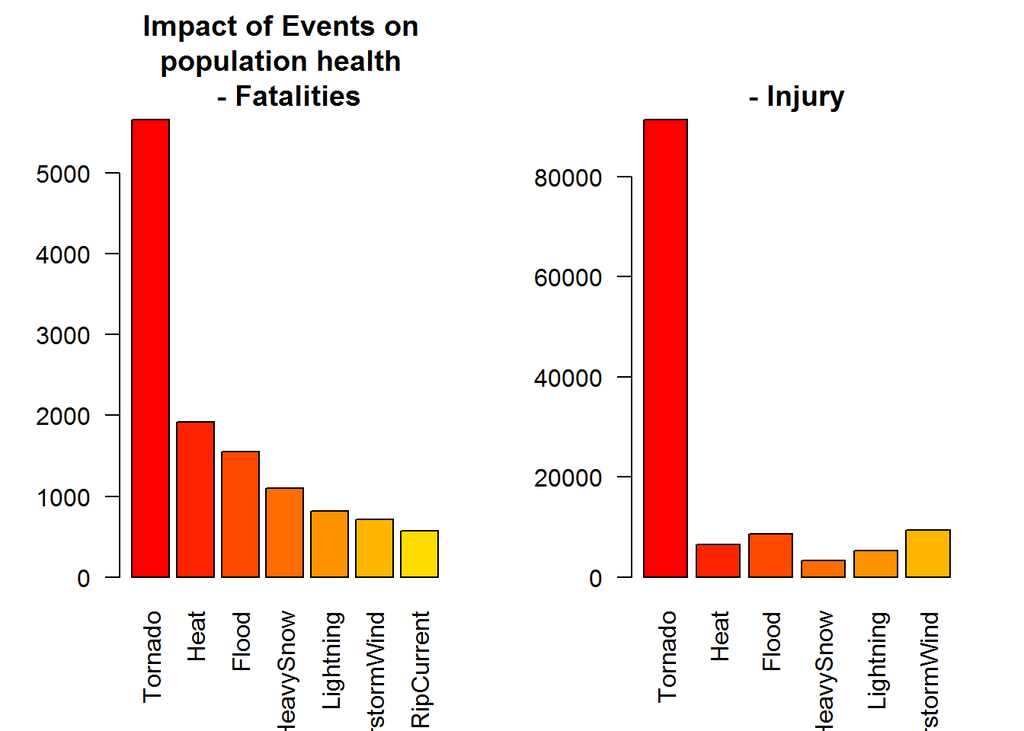

```r
par(mfrow = c(1,2))
barplot(height = events_new_tbl$FATALITIES[which(events_new_tbl$FATALITIES >mean(events_new_tbl$FATALITIES))],names.arg = (events_new_tbl$EventMap[which(events_new_tbl$FATALITIES >mean(events_new_tbl$FATALITIES))]),col = heat.colors(10), las=2 ,border = par("fg"), legend.text = TRUE,main = "Impact of Events on \npopulation health \n - Fatalities")

barplot(height = events_new_tbl$INJURIES[which(events_new_tbl$INJURIES >mean(events_new_tbl$INJURIES))],names.arg = (events_new_tbl$EventMap[which(events_new_tbl$INJURIES >mean(events_new_tbl$INJURIES))]),col = heat.colors(10),las=2, border = par("fg"), legend.text = TRUE,main ="\n\n- Injury")
```

## Analysis 1

The graph shows the impact of natural events on population health, causing 82 % of Fatalities and 89 % of Injuries, Events responsible are Tornado Heat Flood HeavySnow Lightning ThunderstormWind RipCurrent